# Debate Project

Scott Kelleher, Tulsi Gompo, Janalee Thompson

November 30, 2016

# **2016 Presidential Debate: Content Breakdown**

The 2016 presidential debates unfolded slowly as November approached. We watched candidates battle to the bittersweet end trying to convince the American people that they were the better-suited candidate to lead our country. According to CNN.com, over 84 million viewers tuned in to watch Hillary Clinton and Donald Trump debate. There were three debates in total spanning over a couple months. Some would consider these debates amusing (or scary) to say the least, such that terminology never before used in political discussions was broadcasted live for United States citizens and other countries to see in all its’ glory. “Piggy” and “deplorable” were just a couple words that were projected during the debates that caught the attention of some viewers. So what is it that we all do when we want to know more about something? We just “Google it” of course.

### **What were we thinking?**

As each debate unfolded, we wondered how many other people (like us) were using Google to search for termininology used in the debates- like the second amendment for example. Thus, we generated an analysis utilizing debate content and Google search terms. We started checking out Google Trends and tried trending some search terms ourselves. Google Trends is available to the general public with the purpose of displaying global search trends in Google. Google Trends adjusts Google searches by dividing each individual data point by total searches, geography and time range. In other words, this displays the term that was searched in relation to global search-volume. Trends in the data can be graphed by country or city.

Terms such as “second amendment” and “Isis” were some of the first terms we tried that we knew would probably prompt some pretty drastic search trends, which they did. Then, after using Google Trends to search what was intended to be a few words, we ended up searching a copious amount of terms (related and unrelated to the debates)! It was time to get down to business and locate the debate scripts and take some terms used by our candidates for a spin in Google Trends.

### **Five Phrases that had particularly interesting Google search trends with respect to their debate**

Additionally, we were interested in specific terminology searched in Google at the state level. Specifically, which states were Googling more particular terms than others? The following graphic is categorized by state using Google Trends search term data. This time we used the search term “Clinton Foundation” and attained the following result.

```
## # A tibble: 57 × 1
##                                                                         text_c
##                                                                          <chr>
## 1   Well, thank you. Are you a teacher? Yes, I think that that's a very good q
## 2   Well, like everyone else, I've spent a lot of time thinking over the last
## 3   Well, first, let me start by saying that so much of what he's just said is
## 4   ... because everything he just said is absolutely false, but I'm not surpr
## 5                                             In the first debate...[laughter]
## 6   ... I told people that it would be impossible to be fact-checking Donald a
## 7   Well, Martha, first, let me sayand I've said before, but I'll repeat it,
## 8                            Look, it's just not true. And so please, go to...
## 9                                       It was personal e-mails, not official.
## 10                                      Notwell, we turned over 35,000, so...
## # ... with 47 more rows
```

```
## # A tibble: 90 × 1
##                                                                         text_t
##                                                                          <chr>
## 1   Well, I actually agree with that. I agree with everything she said. I bega
## 2   No, I didn't say that at all. I don't think you understood what wasthis w
## 3   And we should get on to much more important things and much bigger things.
## 4   I have great respect for women. Nobody has more respect for women than I d
## 5   I've said things that, frankly, you hear these things I said. And I was em
## 6   And women have respect for me. And I will tell you: No, I have not. And I
## 7   Right now, other nations are taking our jobs and they're taking our wealth
## 8                                        And that's what I want to talk about.
## 9                              Am I allowed to respond to that? I assume I am.
## 10  It's just words, folks. It's just words. Those words, I've been hearing th
## # ... with 80 more rows
```

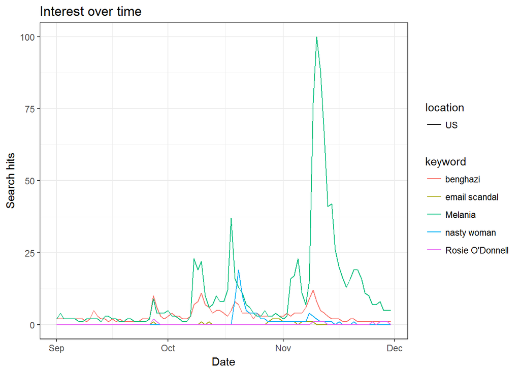

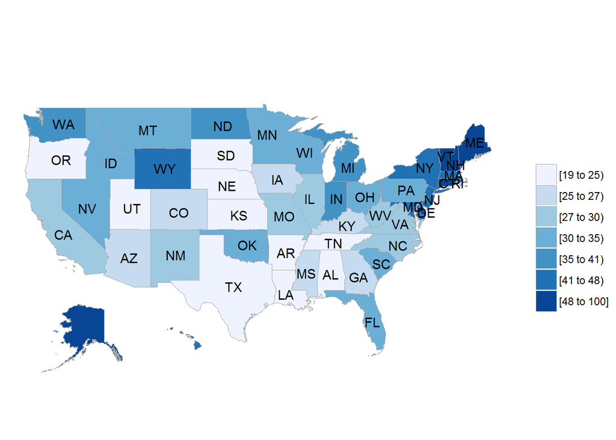

|  | clinton_words | Freq |
| --- | --- | --- |
| 1 | 10 | 1 |
| 2 | 10th | 1 |
| 3 | 12th | 1 |
| 4 | 13 | 1 |
| 5 | 13th | 1 |
| 6 | 170 | 1 |
| 7 | 200 | 1 |
| 8 | 21st | 1 |
| 9 | 23 | 1 |
| 10 | 300 | 1 |

[output cut: 1198 more lines]

[figure not shown]

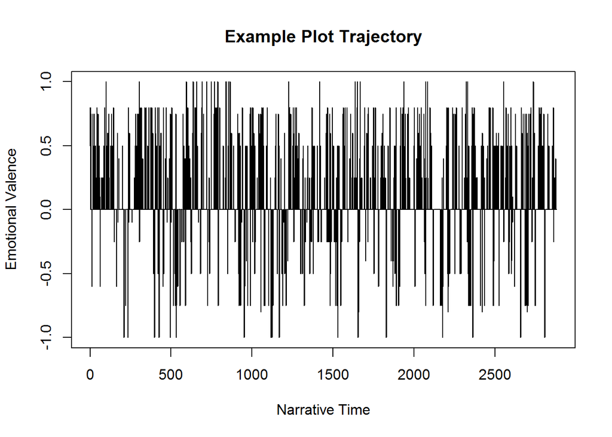

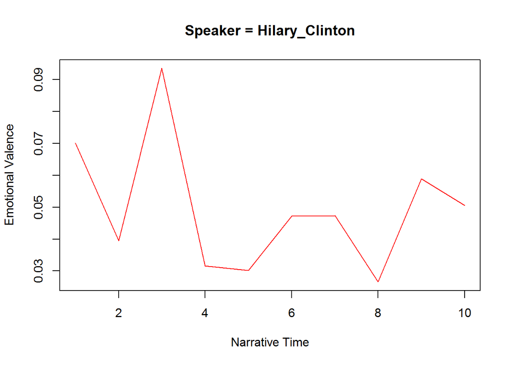

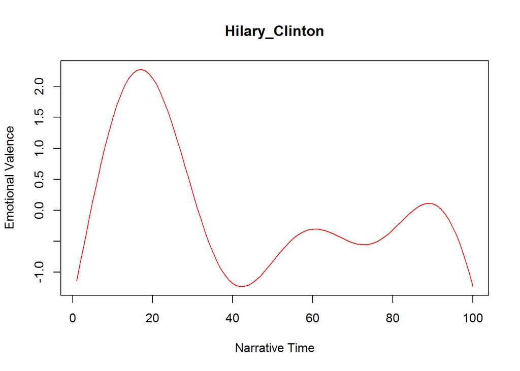

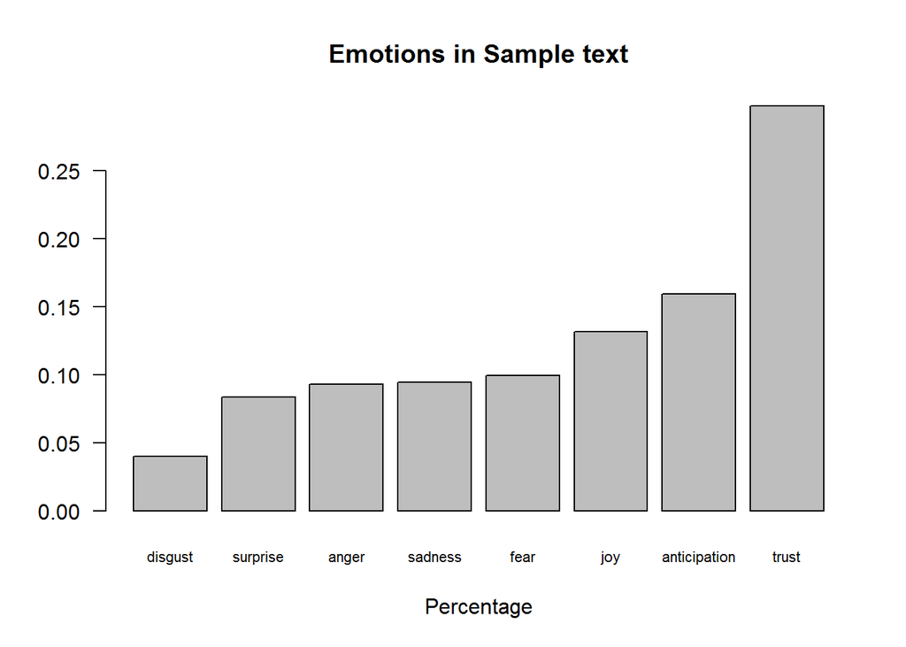

[figure not shown]

[figure not shown]

[output not shown]

[output cut: 1198 more lines]

[figure not shown]